# GCC Cox & Haebig Networks

Trevor Day

2022-06-08

# Setup

## Setup R

```r
knitr::opts_chunk$set(echo = TRUE)

setwd("G:/My Drive/Research/MCDI/MCDI-analysis/code/semnet")

suppressPackageStartupMessages(library(tidyverse))
```

```r
suppressPackageStartupMessages(library(igraph))
suppressPackageStartupMessages(library(qgraph))
suppressPackageStartupMessages(library(patchwork))

source("../mcdi-setup.R")
```

## Setup data

Cox & Haebig (2022) removed some items from the CDI, either because of homophony, missing age of acquisition, or being multiple words.

Also apply func/content labels

```r
##### CDI

sdict <- read_csv(.data("other/s_dict.csv"), show_col_types = FALSE) %>%
  filter(

    # # Words duplicated in two places
    !str_detect(definition,
                "^(can|chicken|clean|drink|dry|fish|orange|slide|swing|watch|water|work)"),

    # No AoA in Cox & Haebig
    !(definition %in% c("about", "above", "an", "babysitter", "basement",
                        "before", "beside", "but", "camping", "child", "could",
                        "country", "does", "downtown", "each", "every", "hate",
                        "hers", "if", "into", "last", "much", "naughty",
                        "none", "nurse", "out", "person", "play", "pen",
                        "poor", "scarf", "snowsuit", "so", "their", "them",
                        "then", "tights", "tray", "us", "vagina", "vanilla",
                        "walker", "was", "where", "when", "which", "wish",
                        "woods", "would", "yesterday", "yourself")),

    !(definition %in% c("babysitter's name", "child's own name",
                        "give me five!", "gonna get you!", "pet's name",
                        "so big!", "this little piggy"))
  ) %>%
  mutate(
    # Seven categories are functional, the rest are content
    group = if_else(category %in% c("connecting_words", "helping_verbs",
                                    "locations", "pronouns", "quantifiers",
                                    "question_words", "time_words"),
                    "func", "content")
  )

sdict
```

```
## # A tibble: 597 x 5
##    category definition     item_id type  group
##    <chr>    <chr>          <chr>   <chr> <chr>
##  1 sounds   baa baa        item_1  word  content
##  2 sounds   choo choo      item_2  word  content
##  3 sounds   cockadoodledoo item_3  word  content
##  4 sounds   grrr           item_4  word  content
##  5 sounds   meow           item_5  word  content
##  6 sounds   moo            item_6  word  content
##  7 sounds   ouch           item_7  word  content
##  8 sounds   quack quack    item_8  word  content
##  9 sounds   uh oh          item_9  word  content
## 10 sounds   vroom          item_10 word  content
## # ... with 587 more rows
```

```r
# Load data
load(.data("semnet/associations-child.Rdata"))
head(associations_child)
```

```
##        SOURCE  COND ORDER                          PP_ID LIST_ID   CUE RESP_ID
## 205026  MTurk child     B 30MVJZJNHPRWPZ6PH6JI8MSL7D1J96       1 horse       1
## 205027  MTurk child     B 30MVJZJNHPRWPZ6PH6JI8MSL7D1J96       1 horse       2
## 205028  MTurk child     B 30MVJZJNHPRWPZ6PH6JI8MSL7D1J96       1 horse       3
## 205029  MTurk child     B 31HQ4X3T3VOKP4QOTXVM5WA33D2LS2       1 horse       1
## 205030  MTurk child     B 31HQ4X3T3VOKP4QOTXVM5WA33D2LS2       1 horse       2
## 205031  MTurk child     B 31HQ4X3T3VOKP4QOTXVM5WA33D2LS2       1 horse       3
##        RESPONSE
## 205026     ride
## 205027     play
## 205028     feed
## 205029     ride
## 205030   saddle
## 205031     race
```

# Create edgelist

Filter the associations down to items found in the reduced list of MB-CDI items (`sdict$definition`), then summarize.

```r
assocs <- associations_child %>%
  select(-SOURCE, -COND, -ORDER, -LIST_ID, -RESP_ID) %>%
  mutate(
    across(c(CUE, RESPONSE), as.character)
  ) %>%
  filter(
    CUE %in% sdict$definition,
    RESPONSE %in% sdict$definition,
  ) %>%
  as_tibble()

assocs_tbl <- assocs %>%
  group_by(CUE, RESPONSE) %>%
  summarize(
    n = n()
  ) %>%
  group_by(CUE) %>%
  mutate(
    cue_total = sum(n),
    pct_resp_in_cue = n / cue_total * 100,
    pct_resp_in_cue_ceiling = if_else(pct_resp_in_cue > 33, 33, pct_resp_in_cue)
  )
```

[output not shown]

```r
range(assocs_tbl$n)
```

```
## [1]  1 97
```

Each cue has many responses, but variable. Below is a plot of the distribution of response frequency, i.e. what percent of all responses to a cue were a given cue. The most responses appear only once. This is probably too low of a threshold to be included as an “edge.”

I also plot the mean response rate (solid) and the median (dashed). Responses appearing in more than 33% of the sample are truncated to 33% for plotting only.

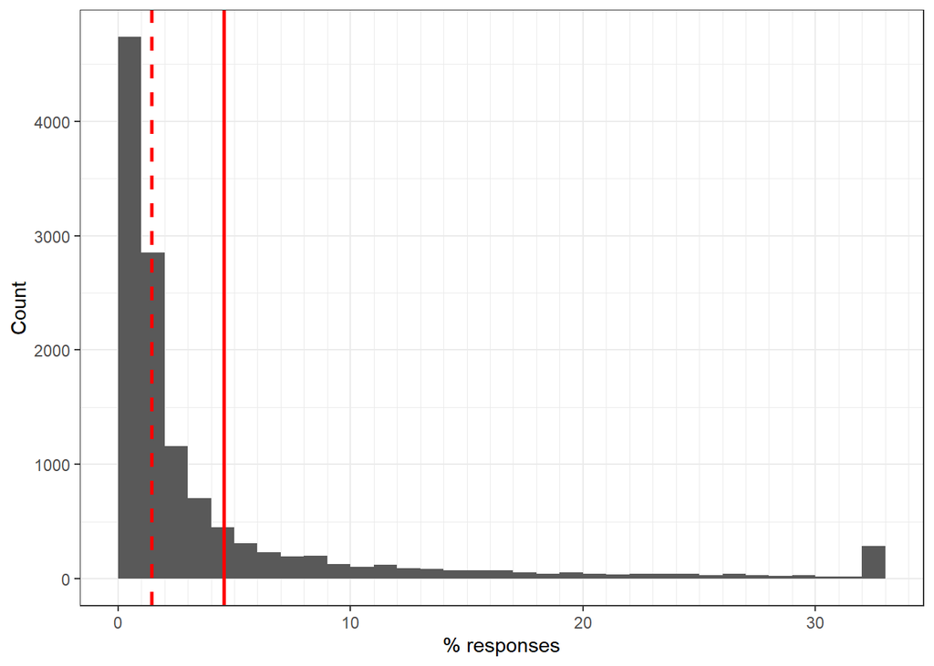

```r
ggplot(assocs_tbl, aes(x = pct_resp_in_cue_ceiling)) +
  geom_histogram(binwidth = 1, boundary = 0) +
  geom_vline(xintercept = c(mean(assocs_tbl$pct_resp_in_cue),
                            median(assocs_tbl$pct_resp_in_cue)),
             color = "red", size = 1,
             linetype = c("solid", "dashed")) +
  scale_x_continuous(breaks = seq(0, 100, by = 10),
                     minor_breaks = 0:100) +
  theme_bw() +
  labs(x = "% responses", y = "Count")
```

I decided to use the more conservative threshold (mean over median), and removed those low-rate edges from the table.

```r
assocs_tbl_high <- assocs_tbl %>%
  filter(
    pct_resp_in_cue > mean(pct_resp_in_cue)
  ) %>%
  select(CUE, RESPONSE, pct_resp_in_cue)

assocs_tbl_high
```

```
## # A tibble: 2,839 x 3
## # Groups:   CUE [569]
##    CUE   RESPONSE pct_resp_in_cue
##    <chr> <chr>              <dbl>
##  1 a     and                 3.81
##  2 a     apple              11.4
##  3 a     first               6.67
##  4 a     is                  3.81
##  5 a     it                 11.4
##  6 a     that                4.76
##  7 a     the                22.9
##  8 a     this                7.62
##  9 a lot big                14.3
## 10 a lot more               48.2
## # ... with 2,829 more rows
```

# Network graphs

The function `edgelist_to_adjacency` takes our associations table and returns an adjacency matrix as well as an ordered list of nodes for doing other things with.

The graph shows the top 50% of edges, but all edges are included in determining the spacing.

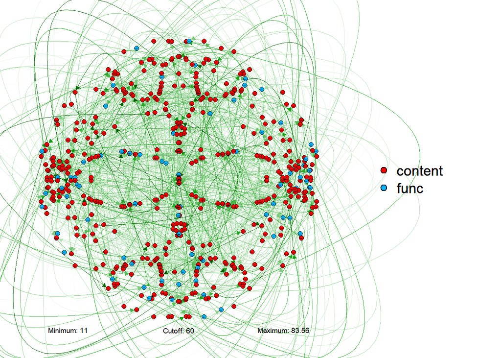

```r
edgelist_to_adjacency <- function(edge) {

  nodes <- c(edge$CUE, edge$RESPONSE) %>%
    unique() %>%
    sort()

  eg <- expand.grid(CUE = nodes, RESPONSE = nodes)

  values <- left_join(eg, edge, by = c("CUE", "RESPONSE"))

  mat <- values %>%
    mutate(
      pct_resp_in_cue = replace_na(pct_resp_in_cue, 0)
    ) %>%
    pivot_wider(names_from = RESPONSE, values_from = pct_resp_in_cue) %>%
    column_to_rownames("CUE")

  return(list(matrix = mat, nodes = nodes))

}

assocs_adj <- edgelist_to_adjacency(assocs_tbl_high)

qgraph(assocs_adj$mat,
       groups = sdict$group[match(assocs_adj$nodes, sdict$definition)],
       minimum = 11, cut = 60, details = TRUE, layout = "spring",
       repulsion = -1, directed = TRUE)
```

However, this graph shows the association between *all* words.

## Grand GCC

The GCC of this graph is below:

```r
g1 <- assocs_tbl_high %>%
  select(CUE, RESPONSE) %>%
  as.matrix() %>%
  graph_from_edgelist()

transitivity(g1, type = "global")
```

```
## [1] 0.1543707
```

# Wordbank

Here, we load in Wordbank data and calculate GCCs for each individual by creating a function that takes a list of words an indivdual knows and returns a reduced assocations list.

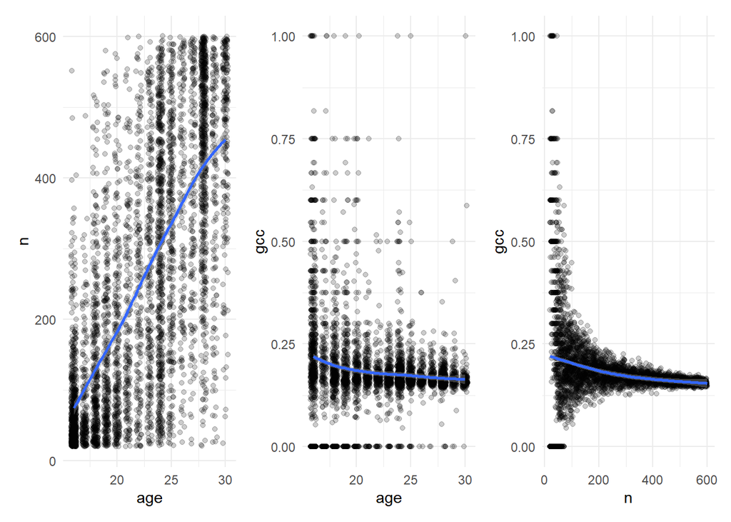

```r
wb0 <- read_data("Wordbank/Wordbank-WS-191105.rds")


get_assoc <- function(assocs_tbl, word_list) {

  assocs_tbl %>%
    filter(
      CUE %in% word_list,
      RESPONSE %in% word_list
    ) %>%
    select(CUE, RESPONSE) %>%
    return()

}

# Load data and create words known list
wb <- wb0 %>%
  filter(
    type == "word"
  ) %>%
  group_by(data_id, age) %>%
  nest() %>%
  mutate(
    words_known = map(data, ~as.character(.x$definition[!is.na(.x$value)])),
    n = map_int(words_known, length)
  ) %>%
  ungroup %>%
  filter(
    # Cut-offs suggested by Haebig
    n >= 20,
    n <= 600
  )

# can't get function to work in map()
wb$assocs <- lapply(wb$words_known, function(x) get_assoc(assocs_tbl_high, x))

# Create graphs and GCCs
wb2 <- wb %>%
  mutate(
    graph = map(assocs, ~graph_from_edgelist(as.matrix(.x))),
    gcc = map_dbl(graph, transitivity)
  )

plot_wb_ageXn <- ggplot(wb2, aes(x = age, y = n)) +
  geom_jitter(alpha = 0.2, width = 0.25) +
  geom_smooth() +
  theme_minimal()

plot_wb_ageXgcc <- ggplot(wb2, aes(x = age, y = gcc)) +
  geom_jitter(alpha = 0.2, width = 0.25) +
  geom_smooth() +
  theme_minimal()

plot_wb_nXgcc <- ggplot(wb2, aes(x = n, y = gcc)) +
  geom_jitter(alpha = 0.2, width = 0.25) +
  geom_smooth() +
  theme_minimal()

plot_wb_ageXn + plot_wb_ageXgcc + plot_wb_nXgcc
```